# A2: Python Analysis Project (individual)

Sosuke Obana

・Introduction

In this report, I explain the research and findings about the bike renting service. I explored the given dataset "bikes_data.xlsx" to gain deep insights. The data showed me trends, habitats and whether conditions which influence customer demand. In this research, I show what I found in the research and provide my insights supported by visualizations. Moreover, I provide answers to the given questions as well as suggestions to improve the bike rental service.

Input dataset and convert data types

```python
# importing packages
import pandas            as pd  # data science essentials
import matplotlib.pyplot as plt # data visualization essentials
import seaborn           as sns # enhanced data visualization


# suppressing user warnings
import warnings # warnings
warnings.simplefilter(action='ignore')


# specifying a file name
file = "bikes_data.xlsx"

# converting data types with a dictionary
data_types = {"Month"         : str,
              "Day of Week"   : str,
              "Season"        : str,
              "Holiday"       : str}


# reading the file into Python through pandas
bikes_data = pd.read_excel(io         = file,
                           sheet_name = 'bikes_data',
                           header     = 0,
                           dtype      = data_types )
```

Insight 1

Seasonal trend for bike rental The demand of bike rental varies depending on Month. The demand hits on the peak in June and It can be seen that demand increases during the summer season, when the weather is generally warm and pleasant. On the other hand, The number of rentals is quite low in winter months. From this analysis, There is a noticeable seasonality, which the company should consider when conduct market research. June is outstanding and increase dramatically from previous month, indication other factor might drive customer demand. Looking into the seasonal trend and unusual demand increase will help the company find the best way to develop future forecast and business strategies.

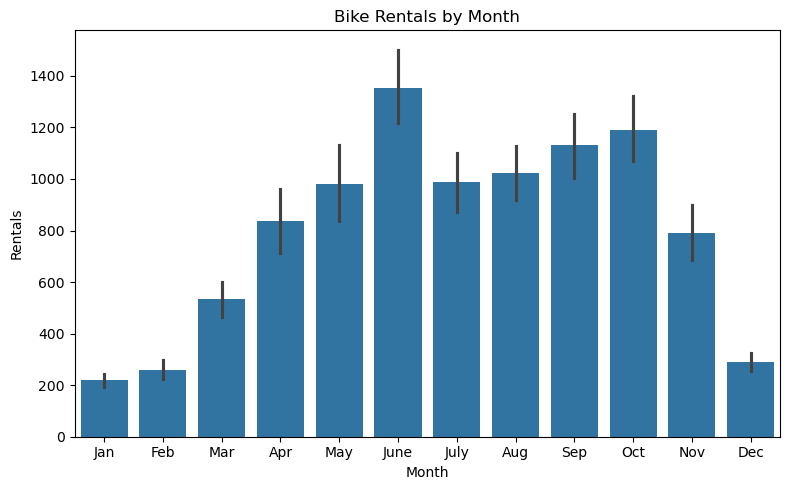

```python
# Developing a bar graph
plt.figure(figsize=(8, 5))
sns.barplot(x    ='Month',
            y    ='RENTALS',
            data = bikes_data,
            order=['Jan','Feb','Mar','Apr','May','June','July','Aug','Sep','Oct','Nov','Dec'])

# Title and axis labels
plt.title('Bike Rentals by Month')
plt.xlabel('Month')
plt.ylabel('Rentals')

# Visualizing the data
plt.tight_layout()
plt.show()
```

The bar graph titled "Bike Rentals by Month" displays the number of bike rentals for each month. The y-axis represents the number of rentals, while the x-axis shows the months from January to December. The data shows strong seasonal demand in summer with the peaking in June and gradual increase from July to October. Conversely, slow demand can be seen in winter. And demand hit the bottom in Jan with approximately 200 bike rental which is only one-seventh of the monthly demand of June.

Insight 2

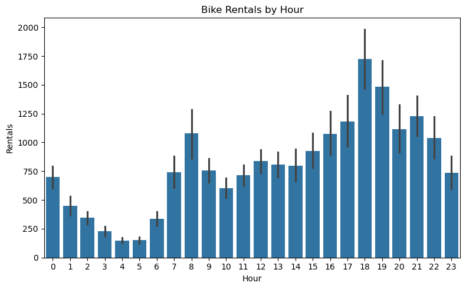

```python
# Developing a bar graph
plt.figure(figsize=(8, 5))
sns.barplot(x    ='Hour',
            y    ='RENTALS',
            data = bikes_data,)

# Title and axis labels
plt.title('Bike Rentals by Hour')
plt.xlabel('Hour')
plt.ylabel('Rentals')

# Visualizing the data
plt.tight_layout()
plt.show()
```

This bar graph represents the number of bike rental by hour throughout the 24-hour day. The y-axis represents the number of rentals, while the x-axis shows each hour from 0 (midnight) to 23 (11 PM). Overall, demand tend to be stronger in evenings than day time. In 18 (6 PM), the demand hit the peak and 1750 bike rides have done in this hour. Additionally, there is significant increase of demand during morning. Major customer behavior will explain these two peak of demand. On the other hand, the number of bike rental decrease though night from 0 AM to 5 AM with the bottom demand in 4 AM.

Insight 3

Correlation between temperature and the number of rentals As the Linear Correlation Heatmap shows below, Weather condition has significant impact on customer demand. Especially, Temperature affects the number of bike trip. As the temperature increases, the demand for bike rental increases. Even though there are some outliers in the scatter plot, The trend line shows a pattern explaining correlation between temperature and rentals. It is found that weather condition is significant factor which we need to consider when develop business strategies. This finding is backed by Mobility Lab's research which says the best condition High temperature, Minimum dew point, Hours of daylight, Average visibility and Precipitation are them most influential factors for bike riders.

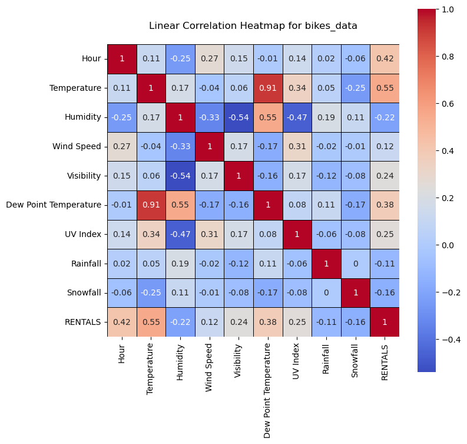

```python
# specifying plot size
fig, ax = plt.subplots( figsize = (8 , 8) )

# converting correlation matrix into a DataFrame
bikes_data_corr = bikes_data.iloc[ : , 1:].corr(method = 'pearson',
                             numeric_only = True).round(decimals = 2)


# developing a coolwarm heatmap
sns.heatmap(data       = bikes_data_corr, # the correlation matrix
            cmap       = 'coolwarm'   , # changing to MEDIUM colors
            square     = True         , # tightening the layout
            annot      = True         , # should there be numbers in the heatmap
            linecolor  = 'black'      , # lines between boxes
            linewidths = 0.5          ) # how thick should the lines be?


# title and displaying the plot
plt.title(label = """
Linear Correlation Heatmap for bikes_data
""")


# visualizing the data
plt.show(block = True)
```

The heatmap displays linear correlations between data in "bikes_data.xlsx". This heatmap uses warm colors to represent strong correlations and cool colors to indicate negative relationships. The strongest correlated variable is between Temperature and RENTALS (0.55). Hour also shows a moderate positive correlation (0.42). These are suggesting that weather customer demand depend on temperature and hours. On the other hand Humidity influence RENTALS in a negative way (-0.22), meaning it reduce customer demand for rental bike.

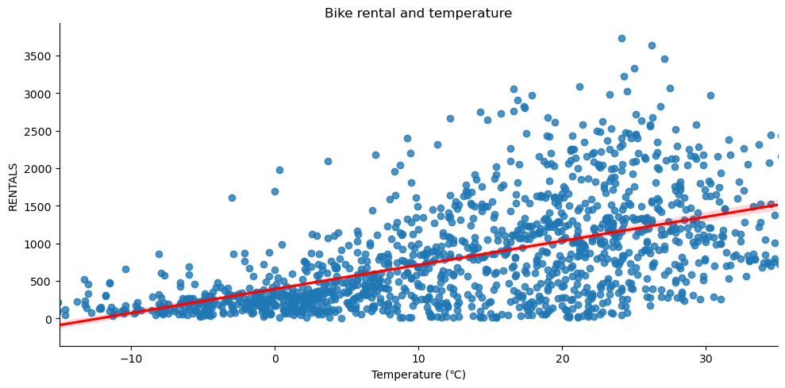

```python
# instantiating an lmplot for carat and price
sns.lmplot(x       = 'Temperature' , # x-axis feature
           y       = 'RENTALS' , # y-axis feature
           hue     = None    , # categorical data for subsets
           scatter = True    , # renders a scatter plot
           fit_reg = True    , # renders a regression line
           aspect  = 2       , # aspect ratio for plot
           data    = bikes_data, # DataFrame where features exist
           line_kws = {'color': 'red'}  # Change the trend line to red
          )



# formatting and displaying the visualization
plt.title       (label  = 'Bike rental and temperature')
plt.xlabel      (xlabel = 'Temperature (℃)'          )
plt.ylabel      (ylabel = 'RENTALS'           )
plt.xlim        (left   = -15, right = 35          )
plt.tight_layout()
plt.show        (block  = True                    )
```

This scatter plot shows the relationship between temperature (℃) and the number of bike rentals. Each point represents a single hour of data, plotting the temperature on the x-axis and rental count on the y-axis. The trend line go up as temperature increase which shows correlation between temperature and customer demand. There are some higher outliers between 20 and 30 degree. THis might be suggesting other factors are working, and it will be worth looking into the exceptions carefully.

・Reference

Echeverria, D. (2024, October 28). Bay Wheels usage has surged this year. Here’s what is driving the uptick. San Francisco Chronicle. https://www.sfchronicle.com/sf/article/bay-wheels-ridership-data-19846883.php

Mobility Lab. (2014, January 27). Explore the Links Between Weather and Capital Bikeshare Ridership. MobilityLab.org (Arlington, VA). https://mobilitylab.org/research/bike/explore-the-links-between-weather-and-capital-bikeshare-ridership/#:~:text=What%20are%20the%20most%20influential,to%20my%20study%2C%20they%20are

・Analysis Questions

1 Why are the majority of users renting bicycles?

2 Are there ideal weather conditions that create high bike rental demand?

3 Actionable steps can the company take in order to take advantage of your insights.

To take advantage of the insights, the company should consider several actions:

Improve operation during peak hours: To commute to work, most customers will begin ride from their neighborhood to office district in morning and vice versa in evening. The company could improve customer satisfaction and the number of rentals by optimizing supply of bikes in appropriate area and hours. For example, The company can track locations of bike and the number of bikes in each station, and should prepare enough bikes in suburbs area to meat high demand.

Optimizing price strategy: From the analysis, it is found that the nicer weather condition help increase customer demand for bike rental. When the company build new price strategy for bike rental service, this data should be taken into consideration. Higher price during summer when demand increases would improve profitability and lower price in winter might create new demand. However, the company need to consider other factors when consider increasing price to ensure the new price influence badly to demand.

Promotion for off-peak usage: Off-peak hours such as daytime on weekday is where the company to look at opportunities to create new demand. For example, Targeting tourists and deliver marketing and advertising to them will help the company make new revenue streamline. I would recommend to conduct marketing research to define target customer and develop market strategies to reach them.

・Conclusion

In conclusion, the data shows seasonality, customer behavioral pattern and preferable weather conditions. These findings are consistent with external information. From the analysis, it is found that customers tend to prefer mild warm sunny days, and the main reason to use bike rental is to commute to avoid rash hour transportation. Additionally the data tells that temperature is the most significant factor to influence the customer demand. The company will benefit from building marketing strategies considering the findings. And the data and trend found in analysis will help company to make an accurate forecasting.